# Tarea 1

[figure not shown]

# Tarea 1: Foundations

**CC6104: Statistical Thinking**

#### **Integrantes :**

- Ignacio Albornoz
- Alejandra Toro

#### **Cuerpo Docente:**

- Profesor: Felipe Bravo M.
- Auxiliares: Benjamín Farías, Martín Paredes
- Ayudantes: Scarleth Betancurt, Emilio Díaz, Kevin Iturra, Renzo Zanca

### **Índice:**

1. Objetivo
2. Instrucciones
3. Referencias
4. Elaboración de Código

### **Objetivo**

Bienvenidas y Bienvenidos a la primera tarea del curso Statistical Thinking. Esta tarea tiene como objetivo evaluar los contenidos teóricos de la primera parte del curso, los cuales se enfocan principalmente en análisis exploratorio de datos y conceptos introductorios de probabilidades. Si aún no han visto las clases, se recomienda visitar los enlaces de las referencias.

La tarea consta de ejercicios prácticos con el fín de introducirlos a la programación en R enfocada en el análisis estadístico de datos.

### **Instrucciones:**

- La tarea se realiza en grupos de **máximo 2 personas**. Pero no existe problema si usted desea hacerla de forma individual.
- La entrega es a través de u-cursos a más tardar el día estipulado en la misma plataforma. A las tareas atrasadas se les descontará un punto por día.
- El formato de entrega es este mismo **Rmarkdown** y un **html** con la tarea desarrollada. Por favor compruebe que todas las celdas han sido ejecutadas en el archivo html.
- Al momento de la revisión tu código será ejecutado. Por favor verifica que tu entrega no tenga errores de compilación.
- No serán revisadas tareas desarrolladas en Python.
- Está **PROHIBIDO** la copia o compartir las respuestas entre integrantes de diferentes grupos.
- Pueden realizar consultas de la tarea a través de U-cursos y/o del canal de Discord del curso.

### **Referencias:**

Slides de las clases:

- [Introduction to Statistical Thinking](https://github.com/dccuchile/CC6104/blob/master/slides/1_1_ST-intro.pdf)
- [Introduction to R](https://github.com/dccuchile/CC6104/blob/master/slides/1_2_ST-R.pdf)
- [Descriptive Statistics](https://github.com/dccuchile/CC6104/blob/master/slides/1_3_ST-explore.pdf)
- [Probability](https://github.com/dccuchile/CC6104/blob/master/slides/1_4_ST-prob.pdf)

Videos de las clases:

- Introduction to Statistical Thinking: [video1](https://youtu.be/X4SqJu6lExM) [video2](https://youtu.be/YbiQU5TTBX4)
- Introduction to R: [video1](https://youtu.be/MbeLD3hWWVo) [video2](https://youtu.be/9W_eWCy86F4) [video3](https://youtu.be/QvFXSw2-1r4) [video4](https://youtu.be/y4JY7klrbfQ)
- Descriptive Statistics: [video1](https://youtu.be/kWNskZ8_98o) [video2](https://youtu.be/_FJ8x9M4b1w) [video3](https://youtu.be/m7VBNZ2mYWI) [video4](https://youtu.be/ylGMJ_aSQk0)
- Probability: [video1](https://youtu.be/R9AVYV73m1M) [video2](https://youtu.be/zubh1jbRiKE) [video3](https://youtu.be/uiwToagp0z4) [video4](https://youtu.be/RlhN3t_VIyw) [video5](https://youtu.be/4kV1dBaeWVc) [video6](https://youtu.be/MGyXc70JdSk)

### **Elaboración de código**

En la siguiente sección deberá resolver cada uno de los experimentos computacionales a través de la programación en R. Para esto se le aconseja que cree funciones en R, ya que le facilitará la ejecución de gran parte de lo solicitado.

```r
set.seed(123)
```

## Pregunta 1: Visualización de Datos

Para esta pregunta usted deberá trabajar en base al conjunto de datos `hearth_database.csv`, el cual esta compuesto por las siguientes variables:

- target: Señala si el paciente tuvo un infarto.
- sex: Sexo de los sujetos de prueba.
- fbs: Azúcar en la sangre con ayunas. Esta variable señala solo si se encuentra <=120 o >120.
- exang: Angina de pecho inducida por el ejercicio.
- cp: Tipo de dolor de pecho.
- restecg: Resultados electrocardiográficos en reposo.
- slope: Pendiente del segmento ST máximo de ejercicio.
- ca: Número de buques principales.
- thal: Thalassemia.
- age: Edad en años.
- trestbps: Presión arterial en reposo.
- chol: colesterol sérico en mg/dl.
- thalach: Frecuencia cardíaca máxima alcanzada.
- oldpeak: Depresión del ST inducida por el ejercicio en relación con el reposo.

En base al dataset propuesto realice un análisis exploratorio de los datos (EDA). Para su análisis enfoquen el desarrollo en las siguientes tareas:

- Obtenga la media, mediana, quintiles y valores máximos desde los datos que componen el dataset.
- Obtenga la Matriz de correlación de Pearson y visualice la relación entre las variables numéricas.
- Visualice los boxplot para las variables numéricas.
- Visualice a través de un histograma como distribuyen las variables respecto a los TARGET.

**Respuesta**

```r
df <- read.csv(file = "hearth_database.csv", header = T, sep = ",")
```

```r
# Considerando solo las variables numericas
categoric <- names(df)[sapply(df, is.character)]
df.categoric <- lapply(df[categoric], function(x) as.numeric(as.factor(x)))
names.categoric <- names(df.categoric)

numeric <- names(df)[sapply(df, is.numeric)]

# Media
media_num <- sapply(df[numeric], mean)
media_cat <- sapply(df.categoric[names.categoric], mean)
print(media_num)
```

```
##       slope          ca        thal         age    trestbps        chol
##   1.3993399   0.7293729   2.3135314  54.3663366 131.6237624 246.2640264
##     thalach     oldpeak
## 149.6468647   1.0396040
```

```r
print(media_cat)
```

```
##   target      sex      fbs    exang       cp  restecg
## 1.544554 1.683168 1.148515 1.326733 1.739274 1.511551
```

```r
# Mediana
mediana_num <- sapply(df[numeric], median)
mediana_cat <- sapply(df.categoric[names.categoric], median)
print(mediana_num)
```

```
##    slope       ca     thal      age trestbps     chol  thalach  oldpeak
##      1.0      0.0      2.0     55.0    130.0    240.0    153.0      0.8
```

```r
print(mediana_cat)
```

```
##  target     sex     fbs   exang      cp restecg
##       2       2       1       1       1       1
```

```r
# Quintiles
quintiles_num <- sapply(df[numeric], quantile, seq(0,1,0.2))
quintiles_cat <- sapply(df.categoric[names.categoric], quantile, seq(0,1,0.2))
print(quintiles_num)
```

```
##      slope ca thal age trestbps  chol thalach oldpeak
## 0%       0  0    0  29       94 126.0      71    0.00
## 20%      1  0    2  45      120 204.0     130    0.00
## 40%      1  0    2  53      126 230.0     146    0.38
## 60%      2  1    2  58      134 254.0     159    1.12
## 80%      2  2    3  62      144 285.2     170    1.90
## 100%     2  4    3  77      200 564.0     202    6.20
```

```r
print(quintiles_cat)
```

```
##      target sex fbs exang cp restecg
## 0%        1   1   1     1  1       1
## 20%       1   1   1     1  1       1
## 40%       1   2   1     1  1       1
## 60%       2   2   1     1  2       2
## 80%       2   2   1     2  3       2
## 100%      2   2   2     2  3       3
```

```r
# Valores maximos
maximos_num <- sapply(df[numeric], max)
maximos_cat <- sapply(df.categoric[names.categoric], max)
print(maximos_num)
```

```
##    slope       ca     thal      age trestbps     chol  thalach  oldpeak
##      2.0      4.0      3.0     77.0    200.0    564.0    202.0      6.2
```

```r
print(maximos_cat)
```

```
##  target     sex     fbs   exang      cp restecg
##       2       2       2       2       3       3
```

```r
# Matriz de correlacion de Pearson de variables numericas
cor(df[numeric])
```

```
##                slope          ca        thal         age    trestbps
## slope     1.00000000 -0.08015521 -0.10476379 -0.16881424 -0.12147458
## ca       -0.08015521  1.00000000  0.15183213  0.27632624  0.10138899
## thal     -0.10476379  0.15183213  1.00000000  0.06800138  0.06220989
## age      -0.16881424  0.27632624  0.06800138  1.00000000  0.27935091
## trestbps -0.12147458  0.10138899  0.06220989  0.27935091  1.00000000
## chol     -0.00403777  0.07051093  0.09880299  0.21367796  0.12317421
## thalach   0.38678441 -0.21317693 -0.09643913 -0.39852194 -0.04669773
## oldpeak  -0.57753682  0.22268232  0.21024413  0.21001257  0.19321647
##                  chol      thalach     oldpeak
## slope    -0.004037770  0.386784410 -0.57753682
## ca        0.070510925 -0.213176928  0.22268232
## thal      0.098802993 -0.096439132  0.21024413
## age       0.213677957 -0.398521938  0.21001257
## trestbps  0.123174207 -0.046697728  0.19321647
## chol      1.000000000 -0.009939839  0.05395192
## thalach  -0.009939839  1.000000000 -0.34418695
## oldpeak   0.053951920 -0.344186948  1.00000000
```

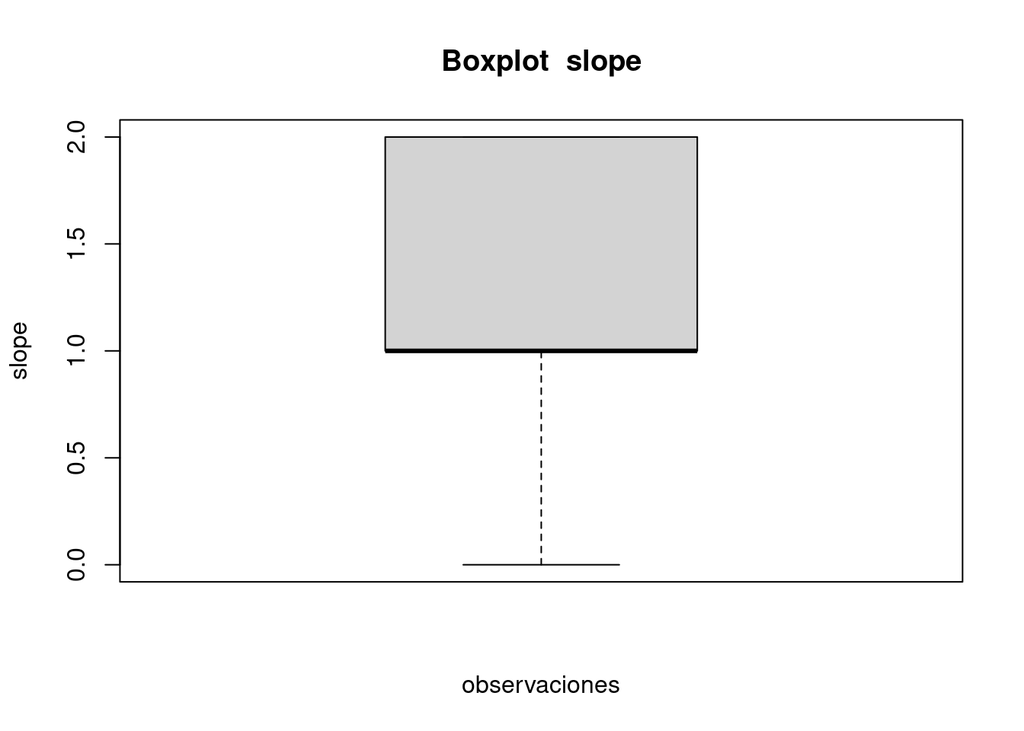

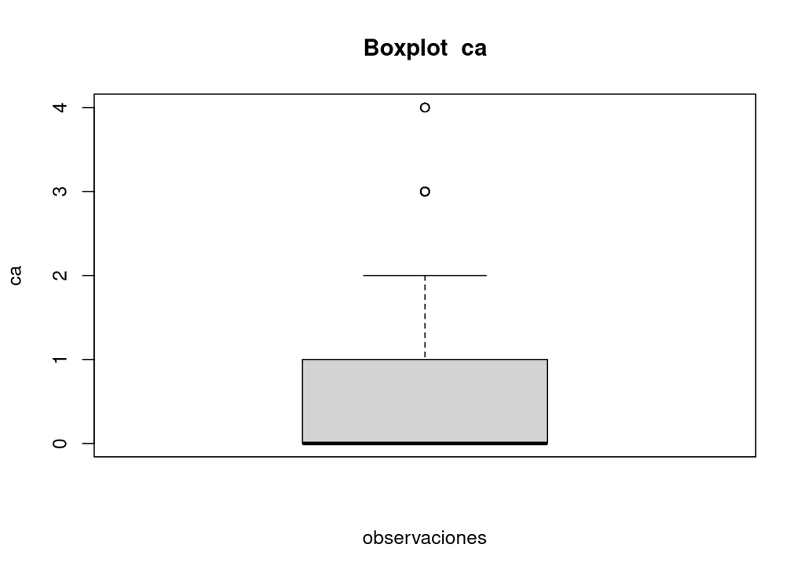

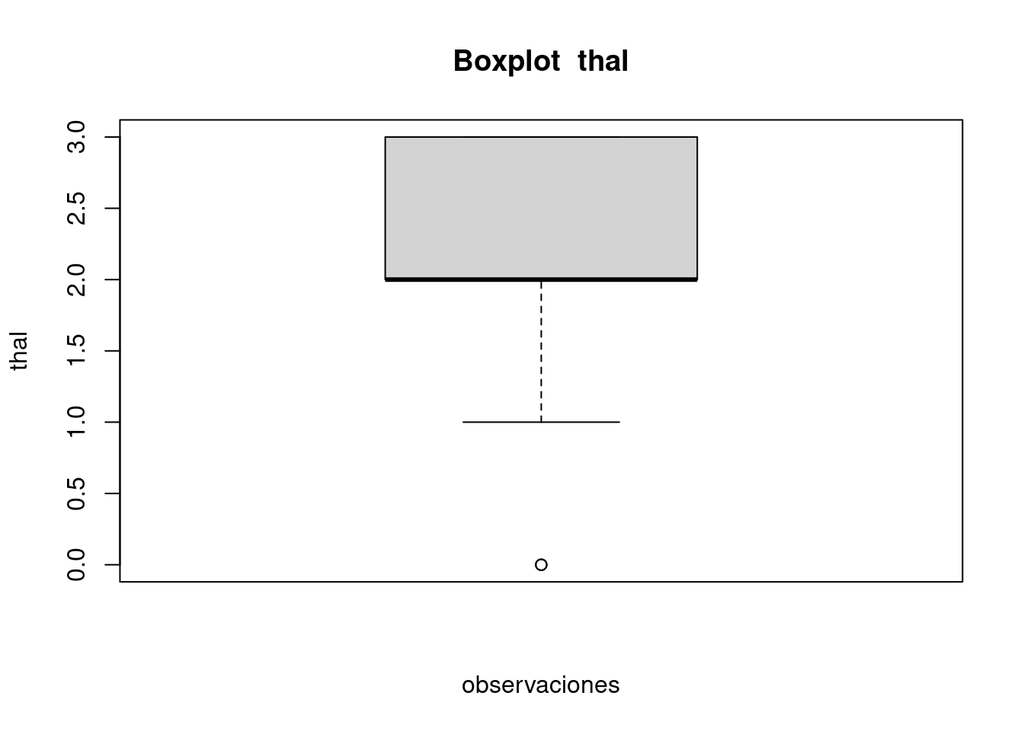

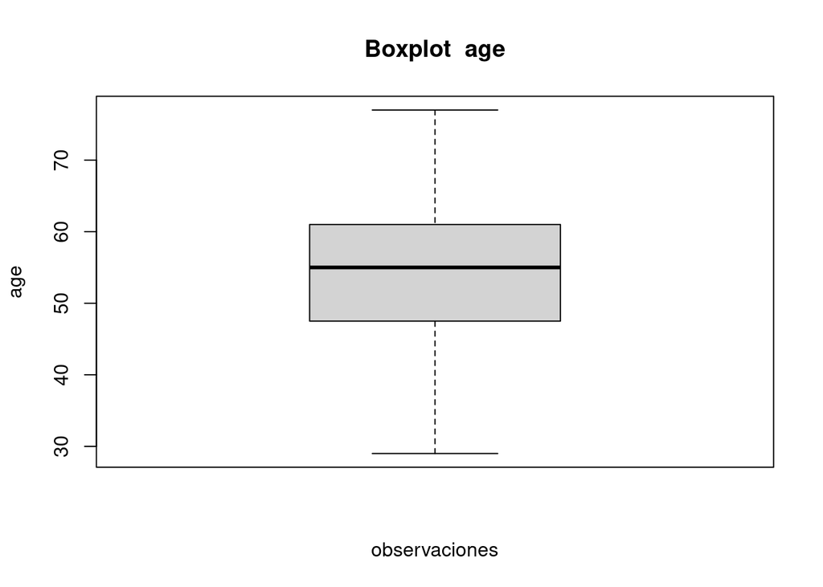

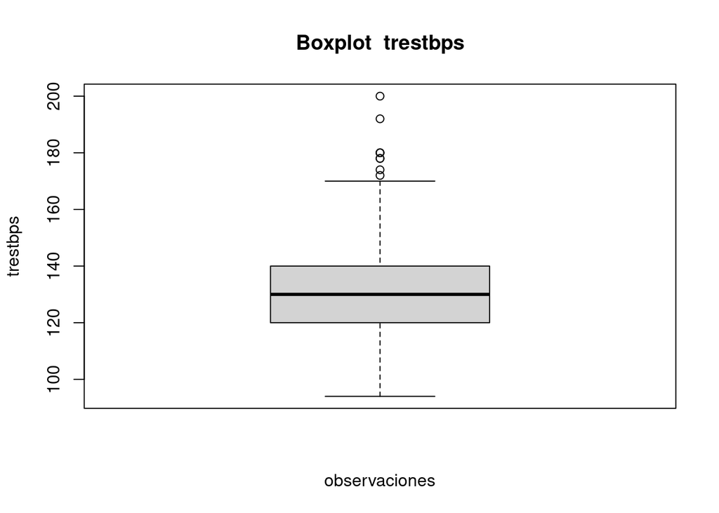

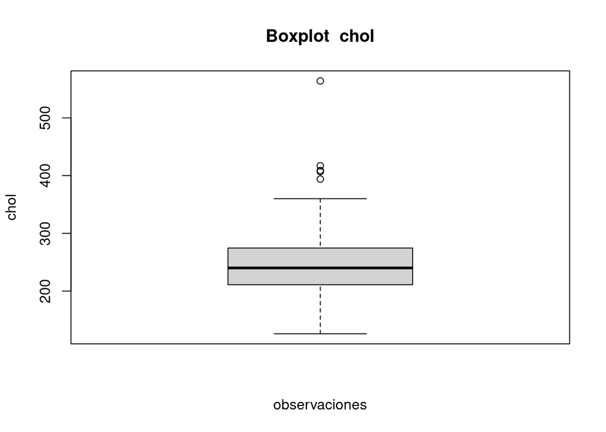

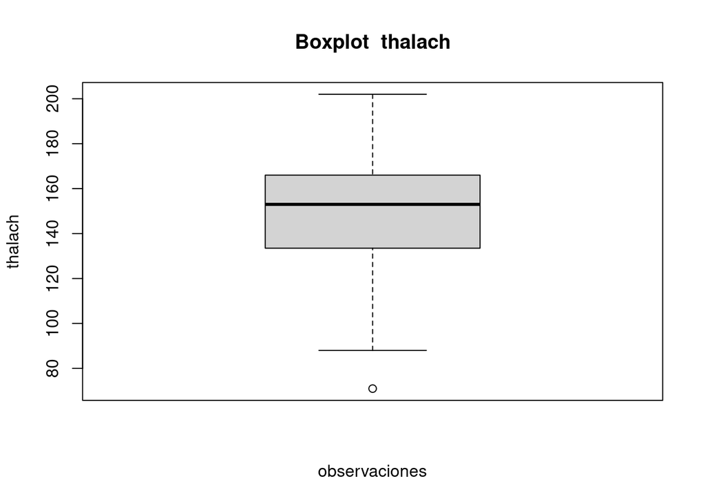

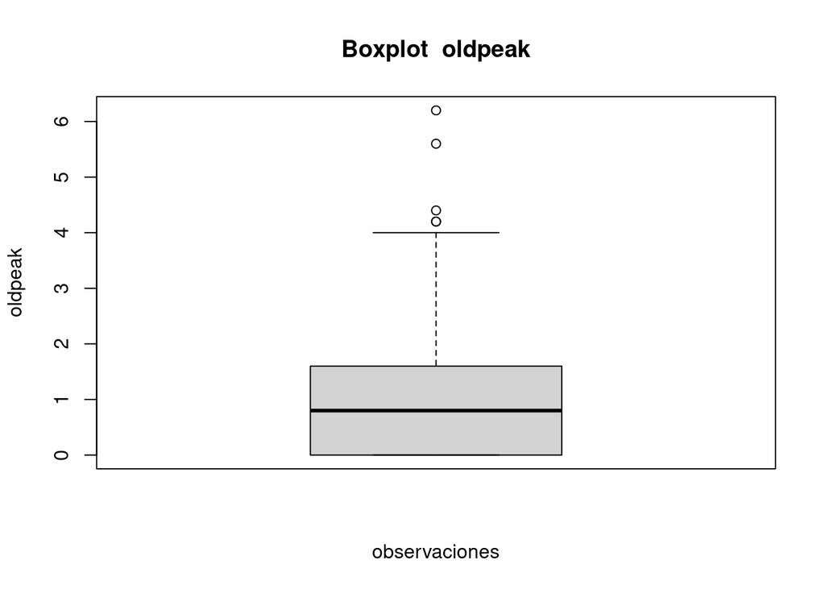

```r
library(ggplot2)
# Boxplot para cada variable numerica
for (var in numeric){
  boxplot(df[[var]], ylab=var, xlab="observaciones", main=paste("Boxplot ", var))
}
```

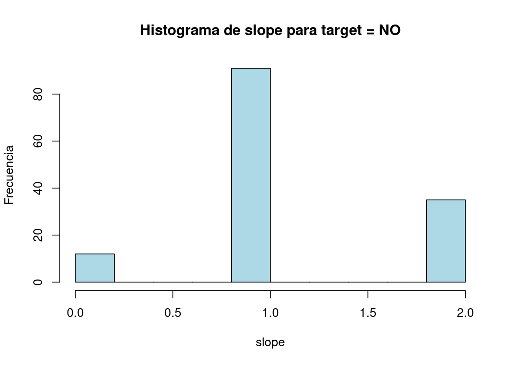

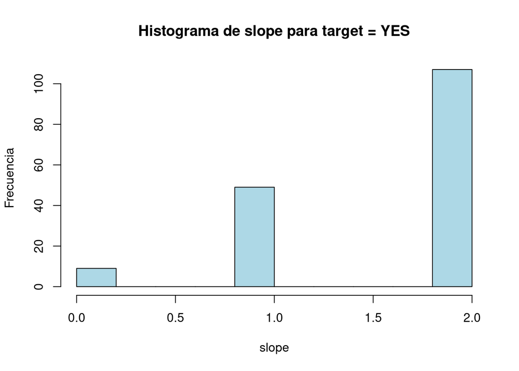

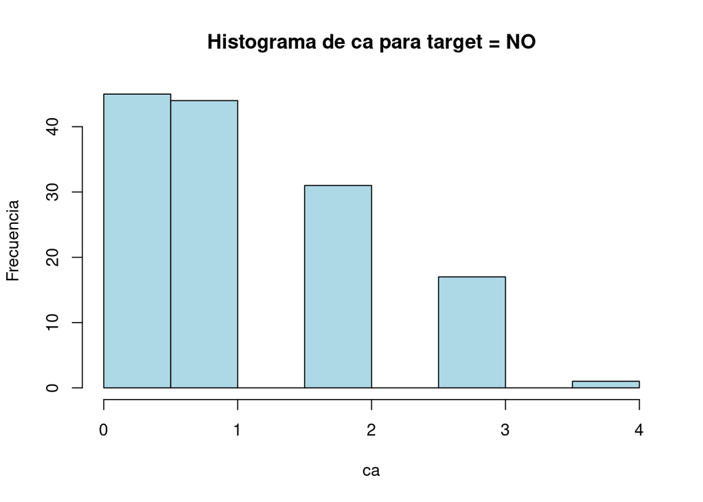

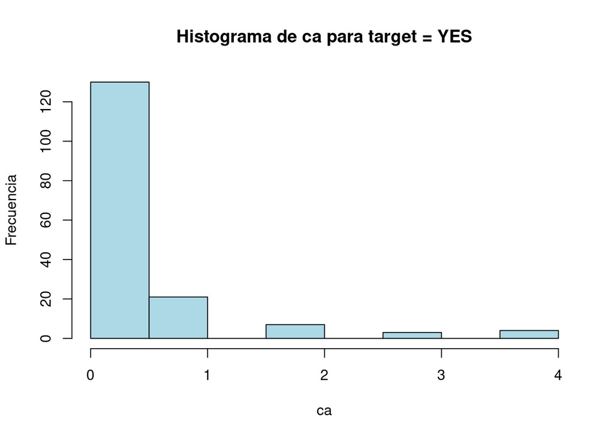

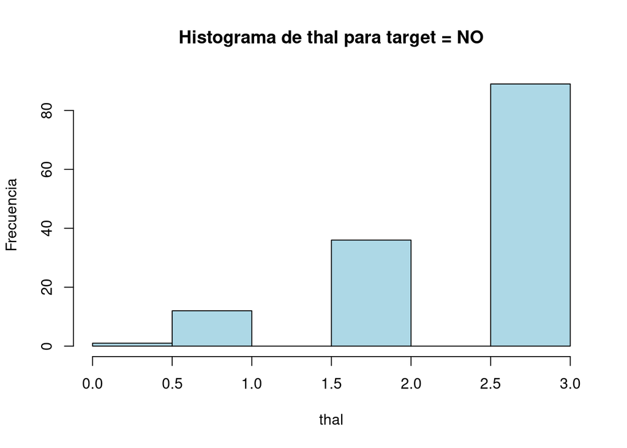

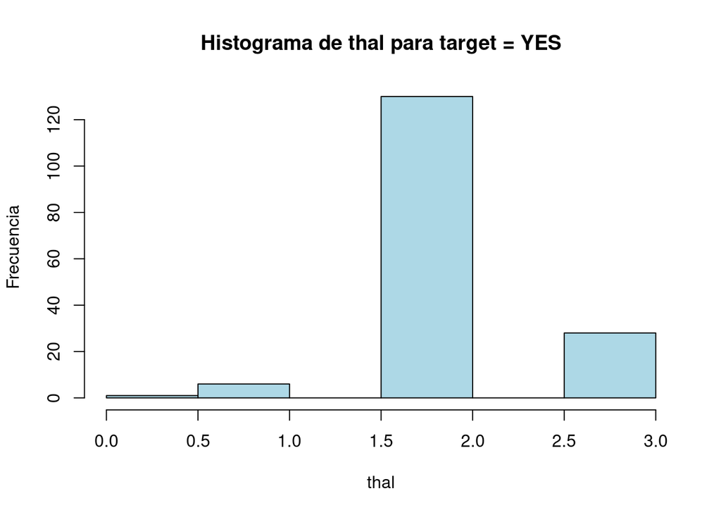

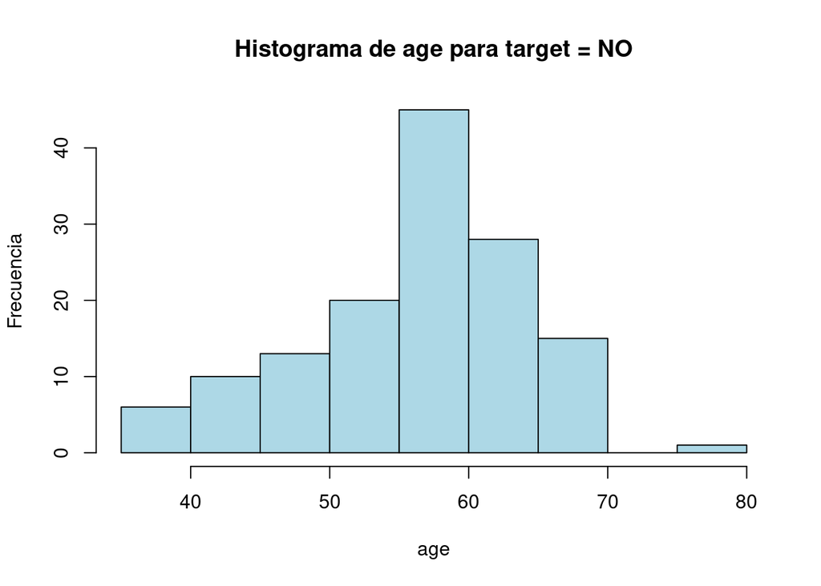

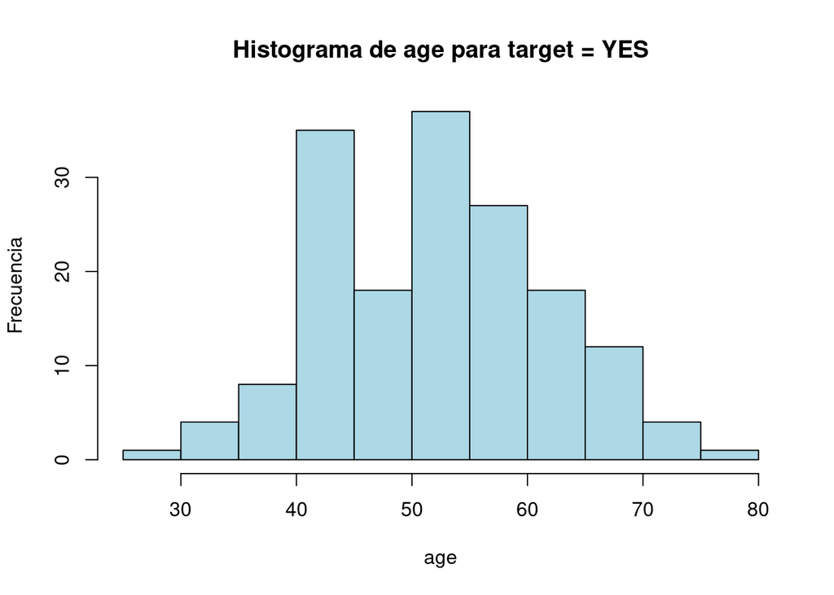

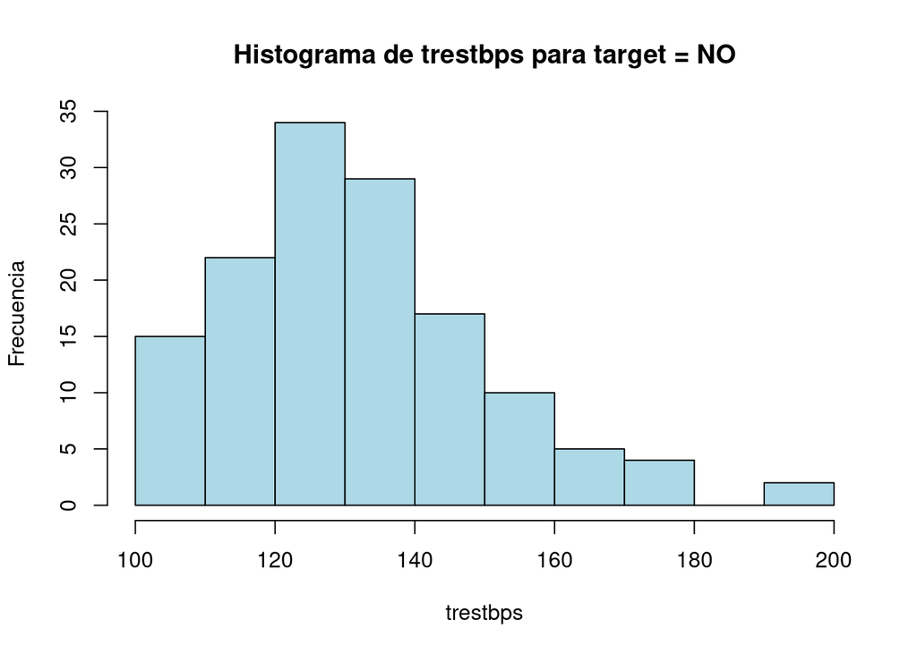

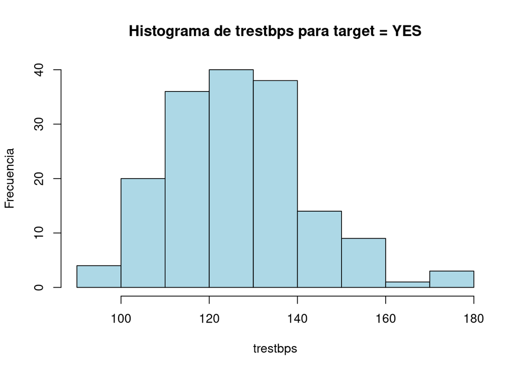

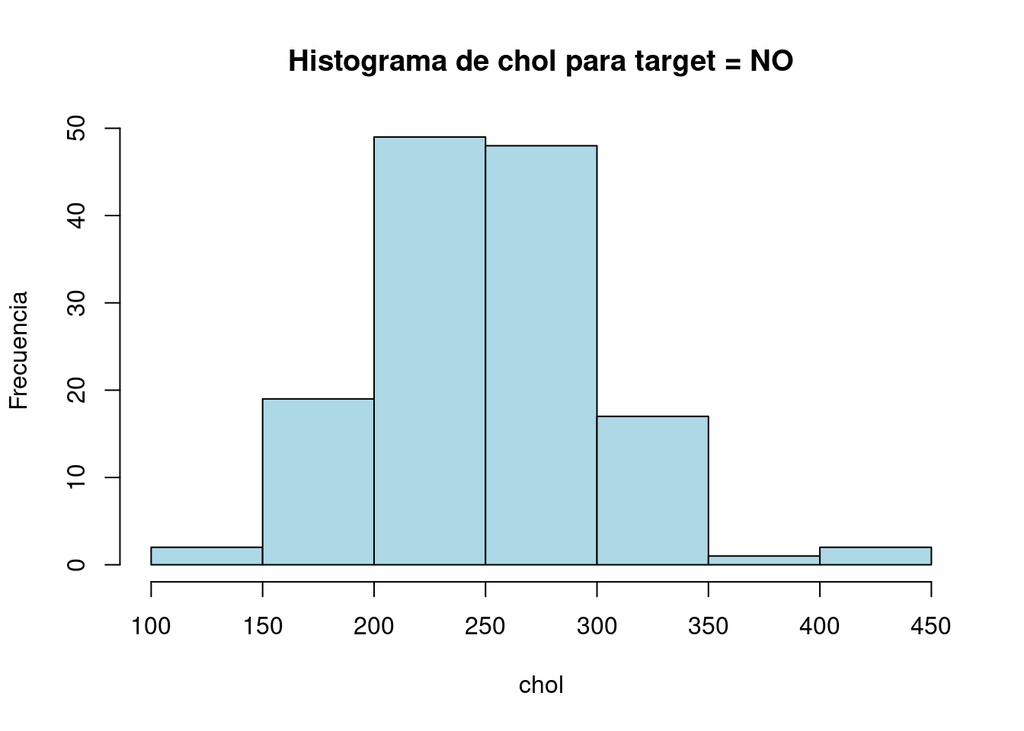

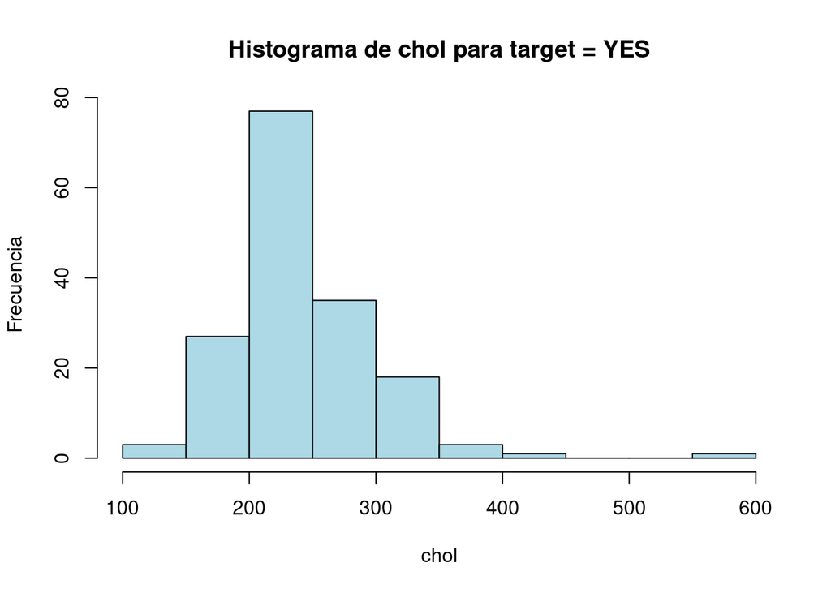

[4 more figures not shown]

```r
# Visualice a través de un histograma como distribuyen las variables respecto a los TARGET

levels_target <- levels(as.factor(df$target))

# histogramas para cada variable numerica segun el target
for (var in numeric) {
  for (level in levels_target) { # YES or NO

    data_to_plot <- df[[var]][df$target == level]
    hist(data_to_plot,
         main = paste("Histograma de", var, "para target =", level),
         xlab = var,
         ylab = "Frecuencia",
         col = "lightblue",
         border = "black")
  }
}
```

## Pregunta 2: Teorema Central del Limite

Pruebe el teorema central del limite aplicando un muestreo de la media en las distribuciones Gamma, Normal y una a su elección. Grafique los resultados obtenidos y señale aproximadamente el numero de muestreos necesarios para obtener el resultado esperado, pruebe esto con las siguientes cantidades de muestreo $\{10,100,1000,5000\}$. ¿El efecto ocurre con el mismo número de muestreo para todas las distribuciones?.

**Respuesta**

```r
# Definición de variables o estructuras necesarias para el muestreo.
n <- 1000
muestreos <- c(10, 100, 1000, 5000)


#my_list <- vector("list", length=muestreos)
mean_gamma_f <- list()
mean_normal_f <- list()
mean_binomial_f <- list()

for(m in muestreos){
  mean_gamma <- numeric(m)
  mean_normal <- numeric(m)
  mean_binomial <- numeric(m)

  # Muesteo distribuciones
  for(i in 1:m){
    sample_gamma <- rgamma(n, shape=2)
    mean_gamma[i] <- mean(sample_gamma)

    sample_normal <- rnorm(n, mean=0, sd=1)
    mean_normal[i] <- mean(sample_normal)

    sample_binomial <- rbinom(n, size=10, prob=0.5)
    mean_binomial[i] <- mean(sample_binomial)
  }

  mean_gamma_f[[as.character(m)]] <- mean_gamma
  mean_normal_f[[as.character(m)]] <- mean_normal
  mean_binomial_f[[as.character(m)]] <- mean_binomial
}
```

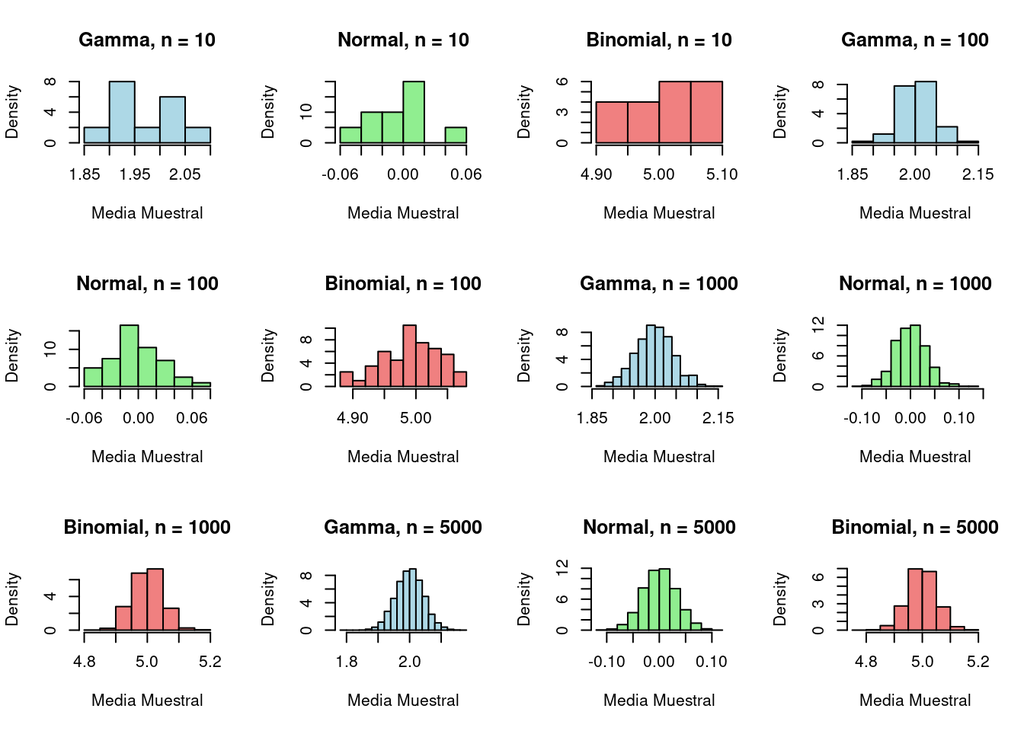

```r
# Código para gráficos
par(mfrow = c(3, 4))

# Hicimos histogramas para ver como son las distribuciones de las medias muestrales
for (m in muestreos) {
  hist(mean_gamma_f[[as.character(m)]],
       main = paste("Gamma, n =", m),
       xlab = "Media Muestral",
       col = "lightblue",
       border = "black",
       prob = TRUE)

  hist(mean_normal_f[[as.character(m)]],
       main = paste("Normal, n =", m),
       xlab = "Media Muestral",
       col = "lightgreen",
       border = "black",
       prob = TRUE)

  hist(mean_binomial_f[[as.character(m)]],
       main = paste("Binomial, n =", m),
       xlab = "Media Muestral",
       col = "lightcoral",
       border = "black",
       prob = TRUE)
}
```

> ¿El efecto ocurre con el mismo número de muestreo para todas las distribuciones?

## Pregunta 3: Ley de los Grandes Numeros.

#### Lanzamiento de monedas

Realice el experimento de lanzar una moneda cargada 1000 veces y observe el comportamiento que tiene la probabilidad de salir cara. Para realizar el experimento considere que la moneda tiene una probabilidad de $5/8$ de salir cara. Grafique el experimento para las secuencias de intentos que van desde 1 a 1000, señalando el valor en que converge la probabilidad de salir cara.

**Respuesta**

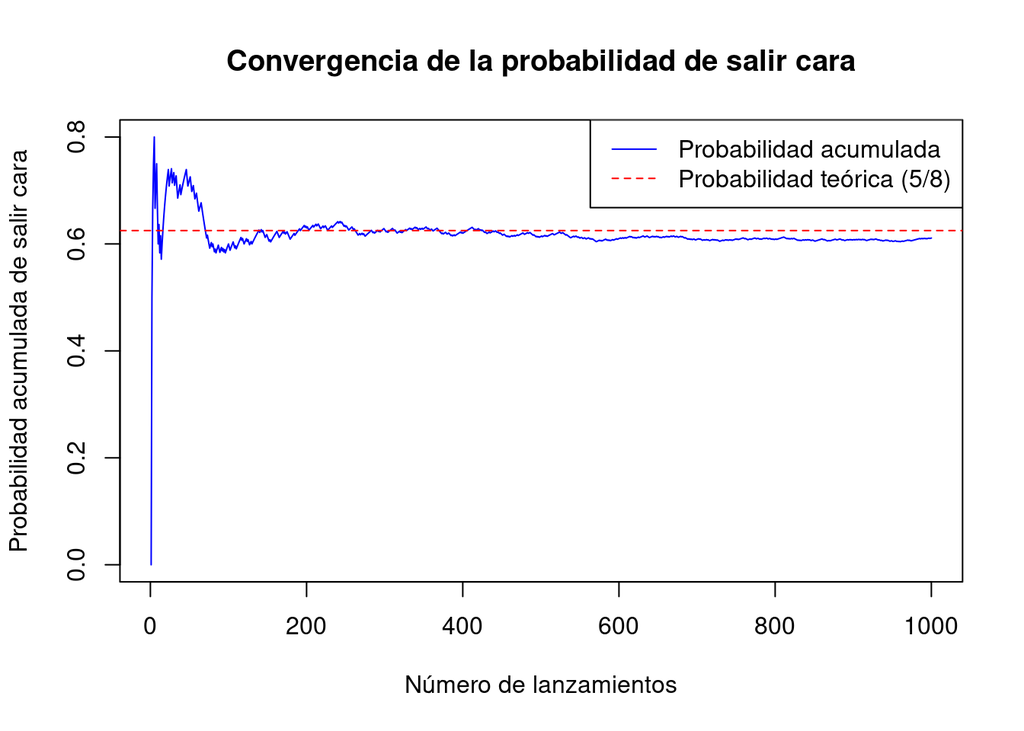

```r
resultados <- numeric(1000)  # Vector para almacenar los resultados

for (lanzamientos in 1:1000) {
  # Simulación de un lanzamiento con probabilidad 5/8 de salir cara
  resultados[lanzamientos] <- rbinom(
    n = 1,
    size = 1,
    prob = 5 / 8
  )
}

# Calcular la probabilidad acumulada de salir cara en cada lanzamiento
probabilidades_acumuladas <- cumsum(resultados) / (1:1000)

# Gráfico de la convergencia
plot(
  1:1000,
  probabilidades_acumuladas,
  type = "l",
  col = "blue",
  xlab = "Número de lanzamientos",
  ylab = "Probabilidad acumulada de salir cara",
  main = "Convergencia de la probabilidad de salir cara"
)

# Añadir línea de referencia para la probabilidad teórica
abline(h = 5 / 8, col = "red", lty = 2)

# Añadir leyenda
legend(
  "topright",
  legend = c("Probabilidad acumulada", "Probabilidad teórica (5/8)"),
  col = c("blue", "red"),
  lty = c(1, 2)
)
```

```r
# Mostrar el valor exacto al que converge en el lanzamiento 500 con contexto
valor_convergencia_500 <- probabilidades_acumuladas[500]
cat(
  "Después de 500 lanzamientos, la probabilidad acumulada de obtener cara es:",
  valor_convergencia_500, "\n"
)
```

```
## Después de 500 lanzamientos, la probabilidad acumulada de obtener cara es: 0.614
```

Al realizar el experimento de lanzar una moneda cargada 1000 veces, con una probabilidad de 5/8 de salir cara, se puede observar que la probabilidad acumulada de obtener cara varía considerablemente al inicio, cuando el número de lanzamientos es bajo. A medida que se realizan más lanzamientos, esta probabilidad acumulada comienza a estabilizarse.

El gráfico obtenido muestra cómo, después de aproximadamente 500 lanzamientos, la probabilidad acumulada de obtener cara comienza a oscilar alrededor del valor teórico de 5/8. En el lanzamiento número 500, la probabilidad acumulada de obtener cara es 0.614, lo cual se aproxima bastante al valor teórico de 5/8 (0.625).

Esta convergencia refleja la Ley de los Grandes Números, que establece que, a medida que el número de ensayos independientes de un experimento aumenta, la media de los resultados obtenidos se aproxima cada vez más al valor esperado teórico.

#### El problema de Monty Hall

Remontándonos en la televisión del año 1963, en USA existía un programa de concursos donde los participantes debían escoger entre 3 puertas para ganar un premio soñado. El problema del concurso era que solo detrás de 1 puerta estaba el premio mayor, mientras que detrás de las otras dos habían cabras como “premio”.

Una de las particularidades de este concurso, es que cuando el participante escogía una puerta, el animador del show abría una de las puertas que no fue escogida por el participante (Obviamente la puerta abierta por el animador no contenía el premio). Tras abrir la puerta, el animador consultaba al participante si su elección era definitiva, o si deseaba cambiar la puerta escogida por la otra puerta cerrada. Un vídeo que puede ayudar a comprender mejor este problema en el siguiente [link](https://www.youtube.com/watch?v=rSa_uiKncEI).

Imagine que usted es participante del concurso y desea calcular la probabilidad de ganar el gran premio **si cambia de puerta** en el momento que el animador se lo ofrece. Utilizando listas/arrays/vectores simule las puertas del concurso, dejando aleatoriamente el premio en alguna posición del array. Hecho esto, genere un numero de forma aleatoria para escoger una de las puerta (posiciones de la estructura), para luego ver si cambiando de posición tendrá mayores posibilidades de ganar el premio. Genere N veces el experimento y grafique cada una de las iteraciones, tal como se hizo en el ejercicio de las monedas.

[figure not shown]

**Respuesta:**

```r
# Creamos una función que simule el juego
montyhall <- function(cambiar) {
  # Puerta con el premio (la posición que tiene el 3 es el premio)
  puertas <- c(0, 0, 0)
  puertas[sample(1:3, 1)] <- 3

  # Elección del participante.
  posicion <- sample(1:3, 1)

  # El animador abre una de las puertas con una cabra
  puerta_abierta <- setdiff(1:3, c(posicion, which(puertas == 3)))
  if (length(puerta_abierta) > 1) {
    puerta_abierta <- sample(puerta_abierta, 1)
  }

  # Si el participante decide cambiar de puerta
  if (cambiar) {
    eleccion <- setdiff(1:3, c(posicion, puerta_abierta))
  } else {
    eleccion <- posicion
  }

  return(eleccion == which(puertas == 3)) # Retornamos TRUE si elige la puerta con el premio
}

# Función que simula N juegos
n_juegos <- function(n, cambiar_puerta) {
  resultados <- replicate(n, montyhall(cambiar_puerta))

  # Calcular la probabilidad de ganar
  probabilidad_ganar <- mean(resultados)

  # Graficar la probabilidad acumulada
  plot(cumsum(resultados) / (1:n), type = "l", col = "blue",
       xlab = "Número de juegos", ylab = "Probabilidad acumulada de ganar",
       main = paste("Probabilidad de ganar cambiando de puerta:",
                    round(probabilidad_ganar, 3)))

  # Añadir línea de referencia para la probabilidad
  abline(h = probabilidad_ganar, col = "red", lty = 2)

  return(probabilidad_ganar)
}
```

```r
# Generar N veces el experimento y graficar cada una de las iteraciones
experimento_montyhall <- function(n, cambiar_puerta) {
  # Inicializar un vector para almacenar los resultados
  resultados <- numeric(n)

  # Realizar N experimentos
  for (i in 1:n) {
    resultados[i] <- montyhall(cambiar_puerta)
  }

  # Calcular la proporción acumulada de éxitos
  proporciones <- cumsum(resultados) / (1:n)

  # Definir el título y la probabilidad teórica según si se cambia o no de puerta
  if (cambiar_puerta) {
    titulo <- paste("Proporción de ganar cambiando de puerta (N =", n, ")")
    prob_teorica <- '2 / 3'
    prob_teorica_num <- 2 / 3
    prob_teorica_title <-" cambiando de puerta  "
    mensaje <- paste("Proporción final de ganar cambiando de puerta después de", n, "juegos:")
  } else {
    titulo <- paste("Proporción de ganar NO cambiando de puerta (N =", n, ")")
    prob_teorica <- '1 / 3'
    prob_teorica_num <- 1 / 3
    prob_teorica_title <- " NO cambiando de puerta "
    mensaje <- paste("Proporción final de ganar NO cambiando de puerta después de", n, "juegos:")
  }

  # Graficar los resultados
  plot(1:n, proporciones, type = "l", col = "blue", ylim = c(0, 1),
       xlab = "Número de juegos", ylab = "Proporción acumulada de ganar",
       main = titulo)

  # Añadir línea de referencia para la probabilidad teórica
  abline(h = prob_teorica_num, col = "red", lty = 2)

  # Añadir la leyenda
  legend("bottomright", legend = c("Proporción acumulada",
                                   paste("Probabilidad teórica", prob_teorica_title ,"(", prob_teorica, ")", sep = "")),
         col = c("blue", "red"), lty = c(1, 2))

  # Imprimir el resultado con contexto
  cat(mensaje, proporciones[n], "\n")

  return(proporciones[n])
}
```

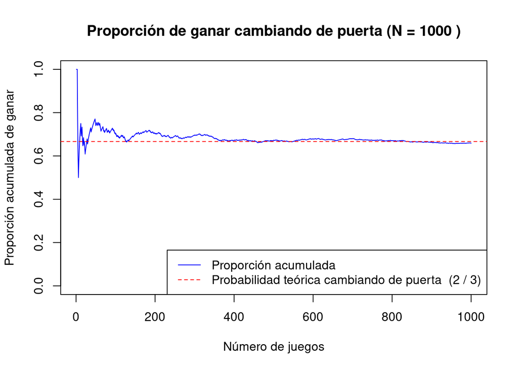

```
## Proporción final de ganar cambiando de puerta después de 1000 juegos: 0.659
```

```
## [1] 0.659
```

```r
# cambiar puerta true y n 1000
experimento_montyhall(n = 1000, cambiar_puerta = TRUE)
```

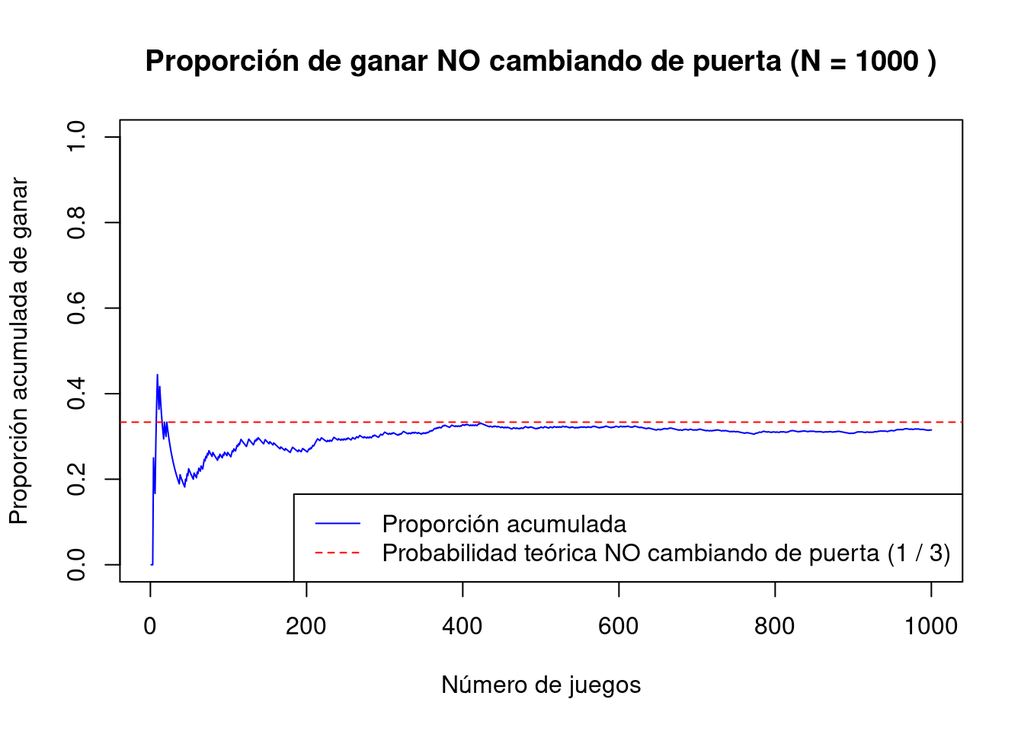

```
## Proporción final de ganar NO cambiando de puerta después de 1000 juegos: 0.315
```

```
## [1] 0.315
```

```r
# cambiar puerta false y n 1000
experimento_montyhall(n = 1000, cambiar_puerta = FALSE)
```

A partir de los resultados obtenidos en los gráficos y en base a la teoría del problema de Monty Hall, se puede llegar a las siguientes conclusiones:

El problema de Monty Hall sugiere que, si decides cambiar de puerta después de que el animador ha revelado una de las puertas con una cabra, **tus probabilidades de ganar el premio aumentan considerablemente**. Esto ocurre porque al cambiar de puerta, se está aprovechando información adicional (la puerta con la cabra que ha sido revelada), lo que hace que las probabilidades de ganar aumenten de 1/3 a 2/3.

Por el contrario, si no cambias de puerta, las probabilidades de ganar permanecen en 1/3, ya que la elección inicial se realizó sin tener información adicional.

**Resultados obtenidos en el experimento**

1. **Proporción de ganar cambiando de puerta:**
   - Después de 1000 juegos, la proporción de éxito cambiando de puerta fue **0.659**, lo que es cercano a la probabilidad teórica de 2/3 (66.67%).
   - Esto confirma que la estrategia de cambiar de puerta **aumenta considerablemente** las probabilidades de ganar el premio.
2. **Proporción de ganar no cambiando de puerta:**
   - Por otro lado, la proporción de éxito al **no cambiar de puerta** fue **0.315**, lo cual es cercano a la probabilidad teórica de 1/3 (33.33%).
   - Esto sugiere que, si decides mantener tu elección original, las probabilidades de ganar el premio siguen siendo bajas.

El experimento realizado muestra que cambiar de puerta es una estrategia mucho más favorable. La proporción final de **0.659** al cambiar de puerta se acerca a la probabilidad teórica de **2/3**, lo que confirma que cambiar de puerta es la mejor opción para maximizar las posibilidades de ganar. Por otro lado, no cambiar de puerta mantiene las probabilidades de éxito en aproximadamente **1/3**, lo cual es significativamente menos ventajoso.

Por lo tanto, se logra verificar empíricamente la teoría de que cambiar de puerta es la mejor opción para aumentar las chances de ganar el concurso.

## Pregunta 4: ¿Independencia?

Ustedes disponen de los dados D1 y D2, los cuales no están cargados y son utilizados para comprobar que $\mathbb{P}(AB)=\mathbb{P}(A)\mathbb{P}(B)$ cuando el evento A es independiente del B. Para estudiar la independencia considere que los eventos A y B se definen de la siguiente manera; sea A el evento dado por los valores obtenidos en el lanzamiento del dado D1, este está compuesto por $A=\{D1=1,D1=2,D1=6\}$. Por otro lado, el evento B viene dado por los valores obtenidos con el dado D2, el que está conformado por $B=\{D2=1,D2=2,D2=3,D2=4\}$. Con esto, tendremos un $\mathbb{P}(A)=1/2$, $\mathbb{P}(𝐵)=2/3$ y $\mathbb{P}(AB)=1/3$. Compruebe de forma gráfica que al realizar 1000 lanzamientos (u otro valor grande que usted desea probar) se visualiza que $\mathbb{P}(AB)=\mathbb{P}(A)\mathbb{P}(B)$.

Hecho lo anterior, compruebe el comportamiento de un segundo grupo de eventos, dados por el lanzamiento de solo el dado D1. Donde, los eventos para D1 quedan definidos como: $A =\{D1=1,D1=2,D1=6\}$ y $B=\{D1=1,D1=2,D1=3\}$. ¿Se observa independencia en este experimento?.

Se le aconseja que para simular los lanzamientos de dados utilice la función `sample()` para generar valores aleatorios entre 1 y 6. Compruebe los números generados por la función con los casos favorables de cada uno de los eventos a ser estudiados.

**Respuesta:**

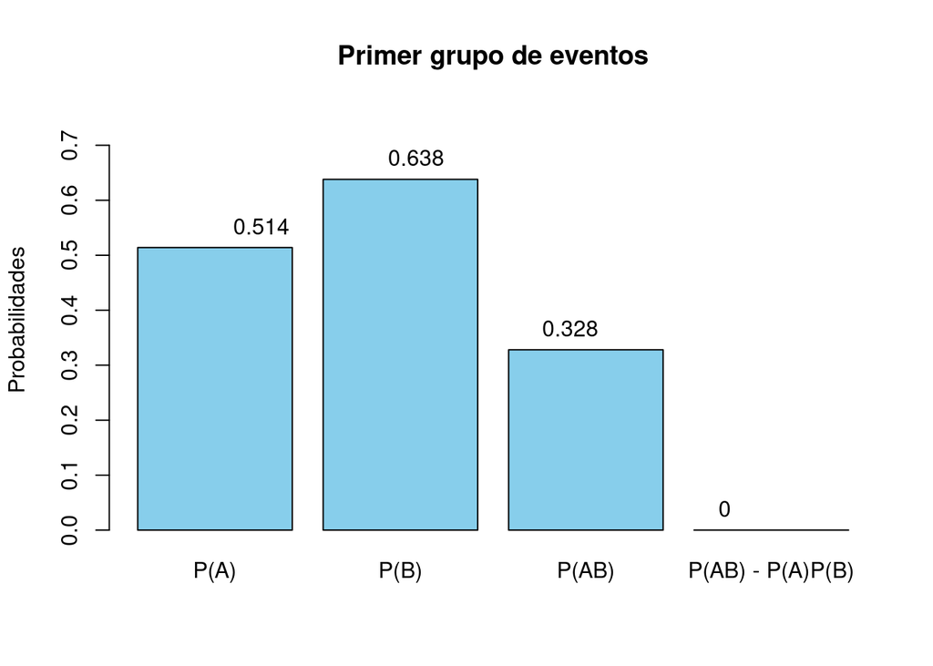

```r
# Primer grupo de eventos
N_lan = 1000 # Numero de lanzamientos


A <- c(1,2,6)
B <- c(1,2,3,4)

D1 <- sample(1:6, N_lan, replace = T)
D2 <- sample(1:6, N_lan, replace = T)

# casos favorables
L_A <- sum(D1 %in% A)
L_B <- sum(D2 %in% B)

L_AB <- sum(
  D1 %in% A & D2 %in% B
)

# calculamos probabilidades
P.a <- L_A / N_lan
P.b <- L_B / N_lan
P.ab <- L_AB / N_lan

diferencia <- P.ab - (P.a * P.b)
valores <- c(P.a, P.b, P.ab, diferencia)
nombres <- c("P(A)", "P(B)", "P(AB)", "P(AB) - P(A)P(B)")

barplot(valores, names.arg = nombres, col = "skyblue",
        main = "Primer grupo de eventos",
        ylab = "Probabilidades",
        ylim = c(0, max(valores) * 1.2))

text(x = 1:length(valores), y = valores,
     label = round(valores, 3), pos = 3)
```

> En el gráfico anterior se puede comprobar que A y B son aproximadamente independientes, ya que para serlo completamente la diferencia entre P(AB) con P(A)P(B) deberia ser cercana a 0.

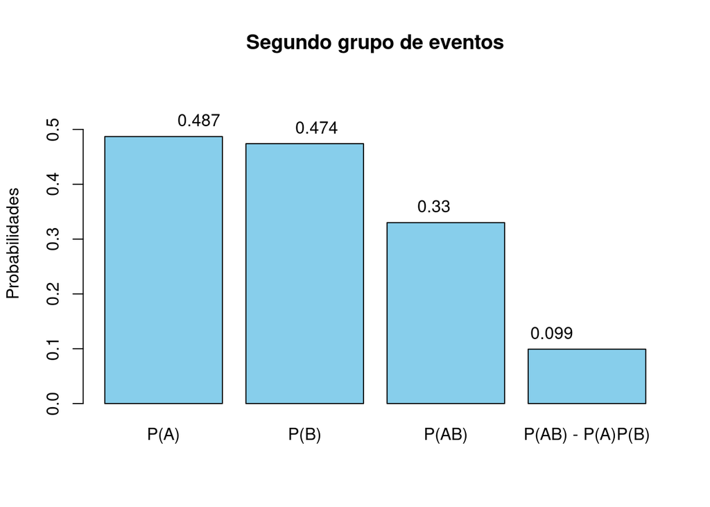

```r
# Segundo grupo de eventos
N_lan = 1000 # Numero de lanzamientos


A <- c(1,2,6)
B <- c(1,2,3)

D1_D2 <- sample(1:6, N_lan, replace = T)

# casos favorables
L_A <- sum(D1_D2 %in% A)
L_B <- sum(D1_D2 %in% B)

L_AB <- sum(
  D1_D2 %in% A & D1_D2 %in% B
)

# calculamos probabilidades
P.a <- L_A / N_lan
P.b <- L_B / N_lan
P.ab <- L_AB / N_lan

diferencia <- P.ab - (P.a * P.b)
valores <- c(P.a, P.b, P.ab, diferencia)
nombres <- c("P(A)", "P(B)", "P(AB)", "P(AB) - P(A)P(B)")

barplot(valores, names.arg = nombres, col = "skyblue",
        main = "Segundo grupo de eventos",
        ylab = "Probabilidades",
        ylim = c(0, max(valores) * 1.2))

text(x = 1:length(valores), y = valores,
     label = round(valores, 3), pos = 3)
```

> Al ser una diferencia positiva, se puede observar que los eventos A y B no son independientes, ya que ambos dependen del mismo dado, lo que tiene sentido pues la ocurrencia de un evento afecta la probabilidad del otro.

## Pregunta 5: La Ruina del Jugador

Un amigo ludópata suyo le comenta que el truco de jugar en el casino esta en no parar de apostar y apostando lo mínimo posible. Ya que así, tienes mas probabilidades de ganar el gran pozo que acumula el juego. Usted sabiendo la condición de su amigo, decide no creer en su conjetura y decide probar esto a través de un experimento.

Para realizar el experimento usted decide asumir las siguientes declaraciones, bajo sus observaciones:

- La probabilidad de ganar en un juego del casino es $8/19$
- Sabe que su amigo *solo* posee siempre fondos en el rango de 0 a 200 dolares.
- Las apuestas como mínimo deben ser igual a 5 dolares.
- El monto de las apuestas no cambia y son siempre igual a la primera. Por ejemplo, si su amigo apuesta 50 dolares, todos los próximos juegos apuesta 50 hasta que se acaba su dinero.
- Usted pierde cuando se le acaban los fondos.

En el primer experimento deberá obtener la evolución de los fondos hasta que el jugador se queda sin fondos para jugar. Puede ser útil seguir la lógica de una moneda cargada para realizar esto. Pruebe esto con una apuesta igual a 5, 25 y 50 graficando los resultados. Comente los resultados obtenidos.

Para la segunda parte de este experimento, con las funciones ya creadas, proyecte 5000 apuestas y obtenga la probabilidad a la que converge el experimento empezando con una apuesta de: 5, 25 y 50. Para este experimento considerar como éxito (1) cuando su función ruina supera los 200 y considere lo contrario cuando su función perdida es menor o igual a 0.

**Respuesta**

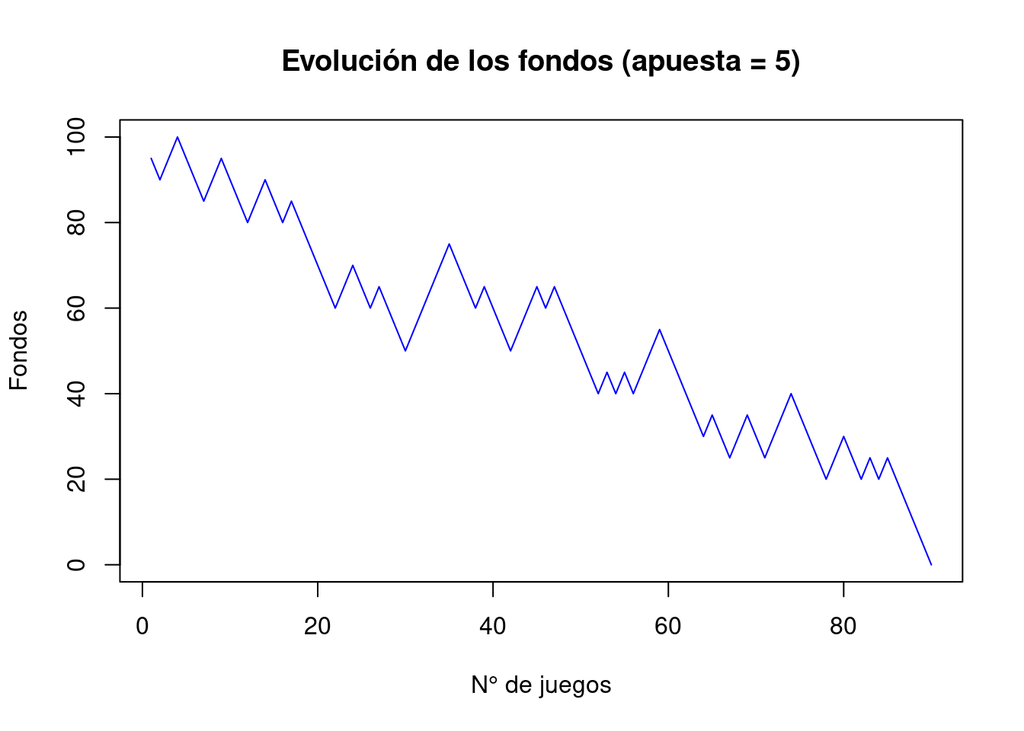

```r
# Función para obtener el desarrollo de las apuestas
ruina <- function(fondos = 100, apuesta = 5){
  vec_fondos <- numeric()  # Vector para almacenar la evolución de los fondos
  while (0 < fondos & fondos < 200) {
    if (runif(1) < 8/19) {  # Probabilidad de ganar
      fondos <- fondos + apuesta
    } else {
      fondos <- fondos - apuesta
    }
    vec_fondos <- c(vec_fondos, fondos)  # Almacena los fondos actuales
  }
  return(vec_fondos) # Devuelve un vector con el desarrollo de los fondos
}

# Graficar los resultados
plot(ruina(), type="l", col="blue", xlab="N° de juegos", ylab="Fondos", main="Evolución de los fondos (apuesta = 5)")
```

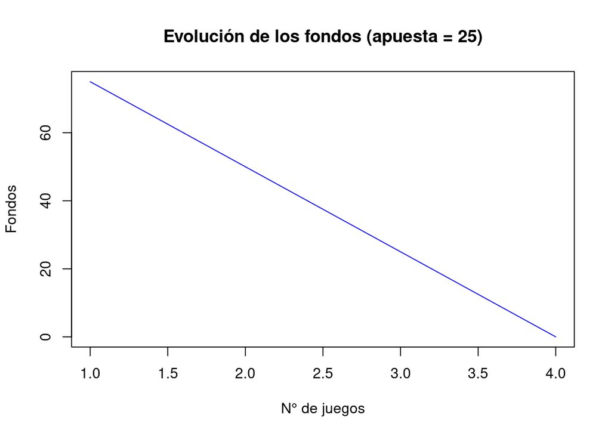

```r
plot(ruina(apuesta = 25), type="l", col="blue", xlab="N° de juegos", ylab="Fondos", main="Evolución de los fondos (apuesta = 25)")
```

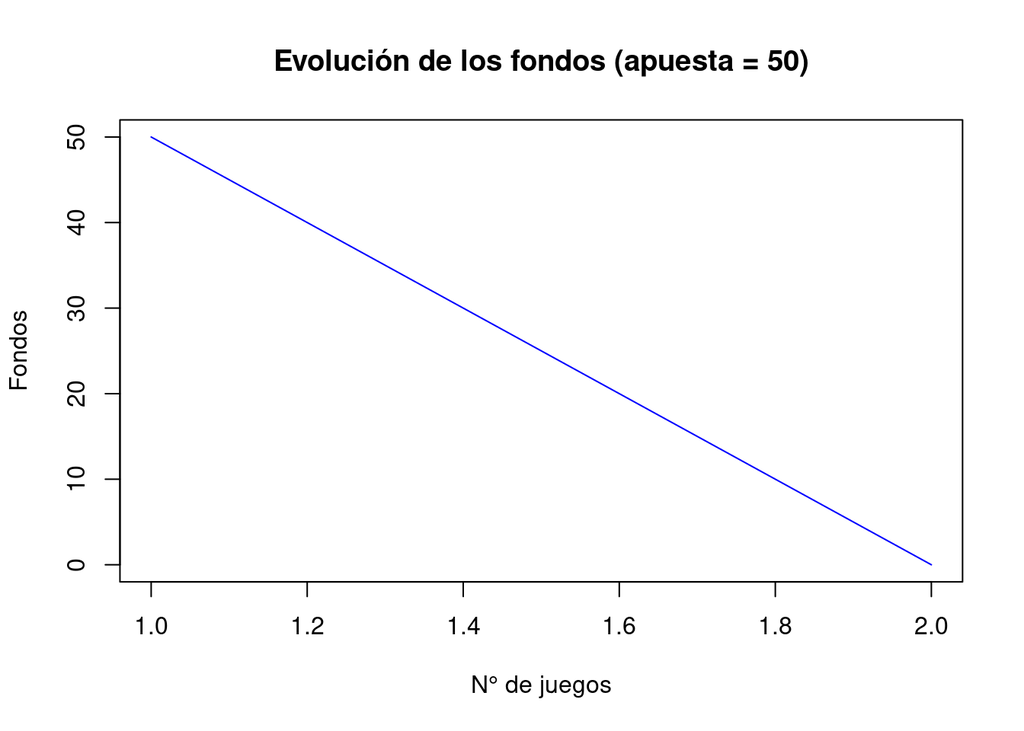

```r
plot(ruina(apuesta = 50), type="l", col="blue", xlab="N° de juegos", ylab="Fondos", main="Evolución de los fondos (apuesta = 50)")
```

En el primer experimento, se obtuvo la evolución de los fondos hasta que el jugador se quedó sin fondos para jugar, utilizando una lógica basada en una moneda cargada. Se realizaron simulaciones para tres valores de apuestas: 5, 25 y 50 dólares. A continuación se presentan los gráficos correspondientes y un análisis de los resultados obtenidos.

- **Evolución de los fondos con apuesta de 5:**

Con una apuesta de 5 dólares, el jugador tiene una trayectoria más larga antes de quedarse sin fondos, pero la tendencia general es a la baja, como era de esperarse dado que la probabilidad de ganar es menor al 50%. El fondo se va reduciendo gradualmente hasta llegar a 0.

- **Evolución de los fondos con apuesta de 25:**

Al aumentar la apuesta a 25 dólares, se observa una mayor volatilidad en la evolución de los fondos. El jugador tiene menos margen para recuperar pérdidas y termina perdiendo todos sus fondos en menos juegos que con la apuesta de 5 dólares.

- **Evolución de los fondos con apuesta de 50:**

La evolución de los fondos refleja que, aunque con apuestas más pequeñas como 5 dólares el jugador puede sobrevivir más rondas, las probabilidades siguen en su contra y eventualmente termina en bancarrota. Las apuestas más grandes, como 25 y 50 dólares, hacen que el jugador se quede sin fondos más rápidamente debido a la mayor volatilidad y riesgo asociado. Estos resultados confirman que la estrategia del jugador de seguir apostando indefinidamente no es efectiva para evitar la ruina, independientemente del tamaño de la apuesta. En algunas de las veces que se corrio el código, tanto con 25 como con 50 dolares a veces se ganaba y se pasaban los 100 dolares, pero de igual manera se llegaba a 0 mucho más rápido a medida que se aumentaba el tamaño de la apuesta.

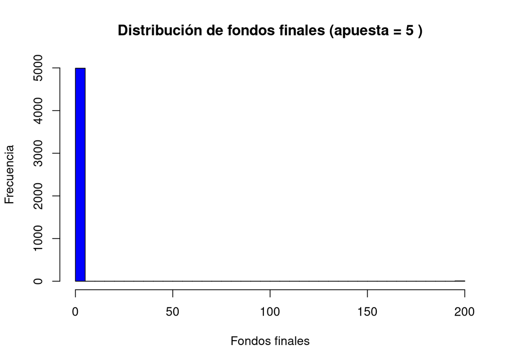

```r
# Función para realizar la simulación 5000 veces y graficar
simular_ruina <- function(n_simulaciones = 5000, apuesta = 5){
  exitos <- 0  # Contador de éxitos
  resultados <- numeric(n_simulaciones)  # Almacena el resultado final de cada simulación

  for (i in 1:n_simulaciones) {
    resultado <- ruina(fondos = 100, apuesta = apuesta)

    # Guardar el resultado final
    resultados[i] <- tail(resultado, n=1)

    # Considerar como éxito si los fondos llegan a 200 o más
    if (resultados[i] >= 200) {
      exitos <- exitos + 1
    }
  }

  # Calcular la probabilidad de éxito
  probabilidad_exito <- exitos / n_simulaciones

  # Graficar el histograma de los resultados finales
  hist(resultados, breaks = 50, col = "blue", main = paste("Distribución de fondos finales (apuesta =", apuesta, ")"),
       xlab = "Fondos finales", ylab = "Frecuencia")

  return(probabilidad_exito)
}

# Proyectar 5000 apuestas y obtener la probabilidad para cada valor de apuesta
prob_5 <- simular_ruina(apuesta = 5)
```

```r
prob_25 <- simular_ruina(apuesta = 25)
```

[figure not shown]